# Analysis of LOL games

## 2 Data files

The whole data have been split into several .csv files :

- banValues.csv : Champion bans in sequential order
- deathValues.csv : Time, victim, killer, assists for every death
- goldValues.csv : Gold values by minute for every team and player
- LeagueofLegends.csv : League, Season, Year, Team Names, Results, Game Length, Player Names, Champion Names
- objValues.csv :Objective type and times (in minutes)

So LeagueofLegends.csv contains the global information about a given game (year, League, etc …) whereas all the other files have the informations / details(columns) of what happened for a given game(row).

## 3 General plots

```python
import pandas as pd
import warnings
import numpy as np
import matplotlib.pyplot as plt
from matplotlib.colors import LinearSegmentedColormap
import seaborn as sns
sns.set_style("whitegrid")
%matplotlib inline
warnings.filterwarnings("ignore", category=RuntimeWarning)
```

```python
# Read in data
df_global = pd.read_csv('LeagueofLegends.csv')
# Basic information
df_global.info()
```

```
<class 'pandas.core.frame.DataFrame'>
RangeIndex: 3760 entries, 0 to 3759
Data columns (total 29 columns):
 #   Column            Non-Null Count  Dtype
---  ------            --------------  -----
 0   MatchHistory      3760 non-null   object
 1   League            3760 non-null   object
 2   Season            3760 non-null   object
 3   Year              3760 non-null   int64
 4   blueTeamTag       3759 non-null   object
 5   bResult           3760 non-null   int64
 6   rResult           3760 non-null   int64
 7   redTeamTag        3760 non-null   object
 8   gamelength        3760 non-null   int64
 9   blueTop           3760 non-null   object
```

[output cut: 21 more lines]

There is 1 missing value in blueTeamTag.

```python
# descriptive statistics
df_global.describe()
```

|  | Year | bResult | rResult | gamelength |
| --- | --- | --- | --- | --- |
| count | 3760.000000 | 3760.000000 | 3760.000000 | 3760.000000 |
| mean | 2015.876862 | 0.544415 | 0.455585 | 37.843617 |
| std | 0.778466 | 0.498090 | 0.498090 | 8.091326 |
| min | 2014.000000 | 0.000000 | 0.000000 | 19.000000 |
| 25% | 2015.000000 | 0.000000 | 0.000000 | 32.000000 |
| 50% | 2016.000000 | 1.000000 | 0.000000 | 37.000000 |
| 75% | 2016.000000 | 1.000000 | 1.000000 | 42.000000 |
| max | 2017.000000 | 1.000000 | 1.000000 | 81.000000 |

### 3.1 Some definitions

Leagues and Seasons:

- CBLOL: Circuito Brasileiro de League of Legends is a tournament that features professional Brazillian teams
- Europe: League of Legends Championship Series (EU LCS) 1st (professional) Europe Berlin
- LCK: League of Legends Champions Korea (LCK) 1st (professional) South Korea Seoul
- LMS: League of Legends Masters Series (LMS) 1st (professional)[LNL] TW/HK/MO Taipei
- Mid-Season_Invitational: is a tournament being hosted by Riot Games between the Spring and Summer splits of the current League season
- North_America: League of Legends Championship Series (NA LCS) 1st (professional) North America Los Angeles
- Season_World_Championship: League of Legends World Championship is the annual professional League of Legends world championship tournament hosted by Riot Games and is the culmination of each season
- Season(time during the year): International, Regional, Spring_Playoffs, Spring_Season, Summer_Playoffs, Summer_Season, Winter_Playoffs Winter_Season

### 3.2 Number of games per League and Year

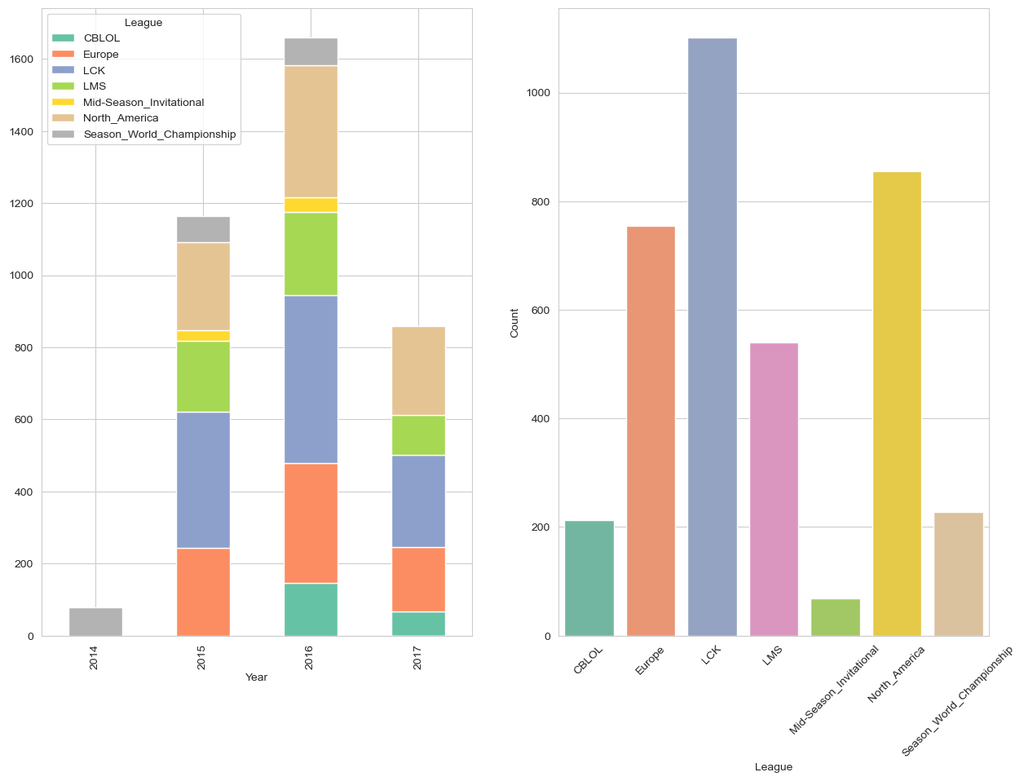

```python
fig, (ax0,ax1) = plt.subplots(nrows=1, ncols=2, figsize=(15,10))

groups0 = df_global.groupby(['League', 'Year']).size().reset_index().pivot(columns='League', index='Year', values=0)
groups0.plot(kind='bar', stacked=True, colormap='Set2', ax=ax0)

groups1 = df_global.groupby(['League']).size().reset_index()
groups1.columns = ['League', 'Count']
ax1 = sns.barplot(x='League', y='Count', data=groups1, hue='League', palette='Set2')
plt.xticks(rotation=45)

plt.show()
```

- So far the LCK league has the most games (at least from this dataset).

### 3.3 Number of games per Season, breakdown per League and Year

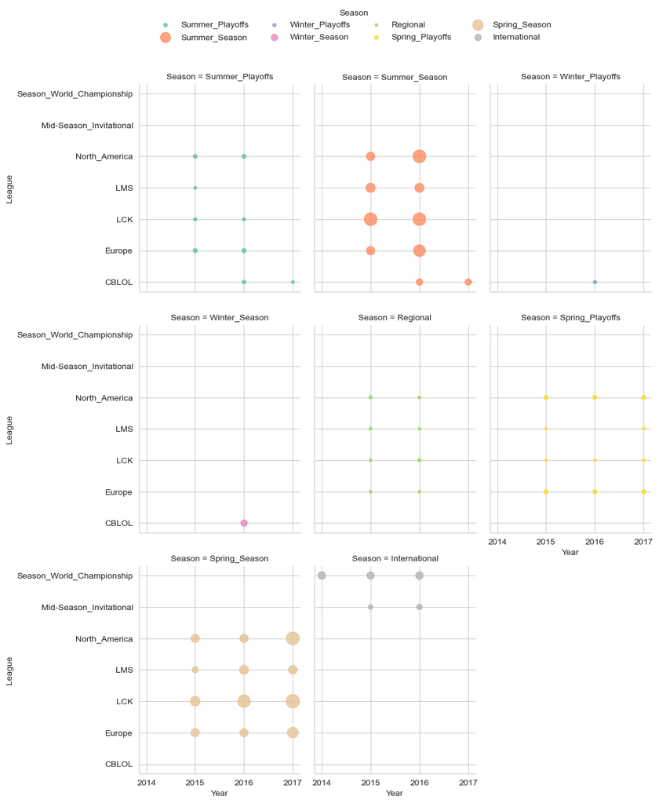

```python
groups = df_global.groupby(['League', 'Season', 'Year']).size().reset_index()
groups.columns = ['League', 'Season', 'Year', 'Count']

g = sns.FacetGrid(groups, col='Season', col_wrap=3, palette='Set2', hue='Season', height=4, aspect=1)
(g.map_dataframe(plt.scatter, "Year", "League", s='Count', alpha=0.8)
    .add_legend(loc='lower left', ncol=4, bbox_to_anchor=(0.2, 1.02, 1, 0.2)))

plt.show()
```

- Winter_Playoffs and Winter_Season occur only for the Brazilian league (CBLOL).
- Spring and Summer_Season are the biggest events so far.

### 3.4 Average length of games

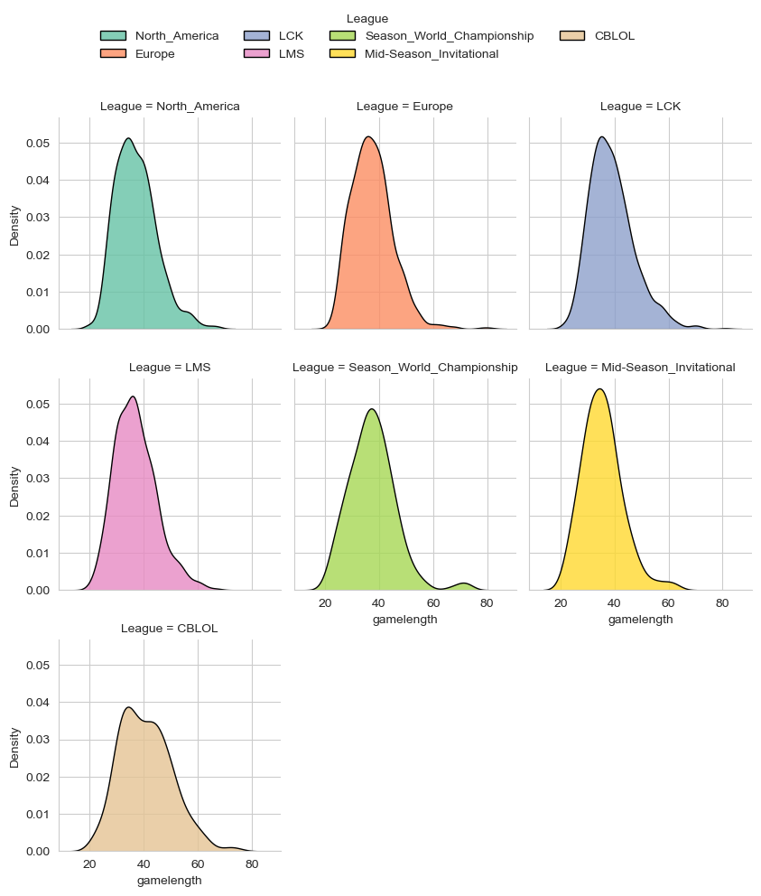

```python
df_AvgLen = df_global[['League', 'Season', 'gamelength']]

g = sns.FacetGrid(df_AvgLen, col='League', col_wrap=3, palette='Set2', hue='League', height=3, aspect=1)
(g.map_dataframe(sns.kdeplot, 'gamelength', fill=True, lw=1, alpha=0.8, ec='black')
    .add_legend(loc='lower left', ncol=4, bbox_to_anchor=(0.1, 1.02, 1, 0.2)))
plt.show()
```

- The small bump for Season_World_Championship is interesting and inindicates that games during this championship (the most prestigious) are more tight.

### 3.5 Number of wins as Blue/Red teams vs. Year

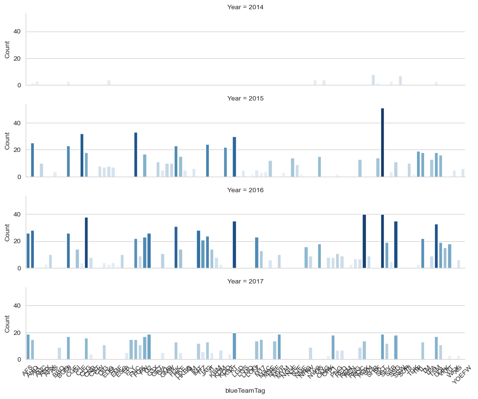

```python
df_global['blueTeamTag'] = df_global['blueTeamTag'].str.upper()
df_Wins = (df_global[df_global['bResult'] == 1][['blueTeamTag', 'bResult', 'Year']]
            .groupby(['blueTeamTag', 'Year'])
            .size()
            .reset_index()).sort_values(['blueTeamTag'])
df_Wins.columns = ['blueTeamTag', 'Year', 'Count']

g = sns.FacetGrid(df_Wins, col='Year', col_wrap=1, palette='Blues', height=2, aspect=5, hue='Count')
(g.map_dataframe(sns.barplot, x='blueTeamTag', y='Count', order = df_Wins['blueTeamTag']))
plt.xticks(rotation=45)
plt.show()
```

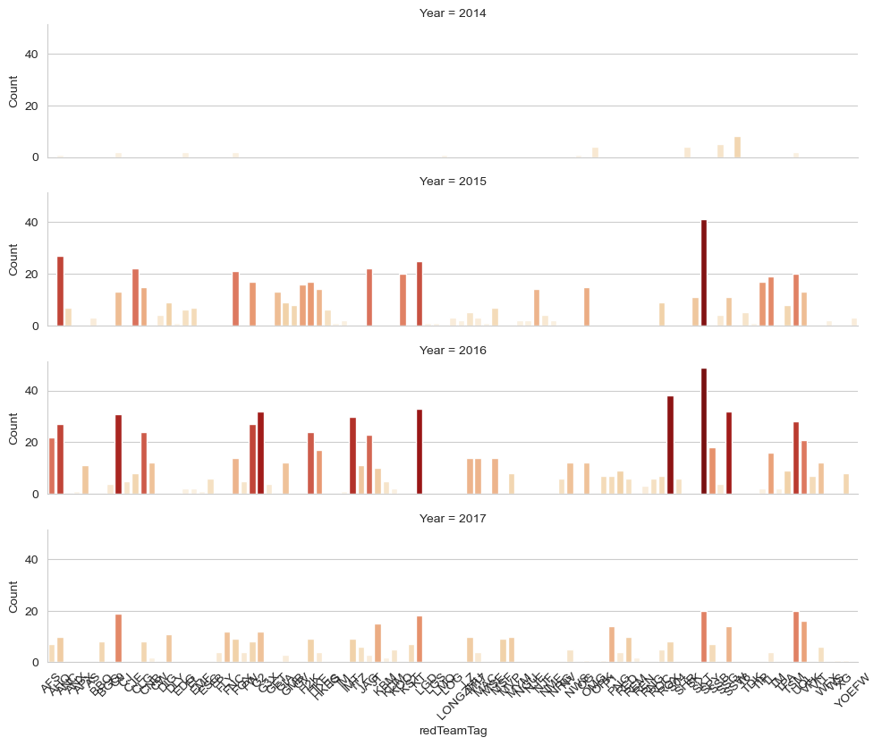

```python
df_global['redTeamTag'] = df_global['redTeamTag'].str.upper()
df_Wins = (df_global[df_global['rResult'] == 1][['redTeamTag', 'bResult', 'Year']]
            .groupby(['redTeamTag', 'Year'])
            .size()
            .reset_index()).sort_values(['redTeamTag'])
df_Wins.columns = ['redTeamTag', 'Year', 'Count']

g = sns.FacetGrid(df_Wins, col='Year', col_wrap=1, palette='OrRd', height=2, aspect=5, hue='Count')
(g.map_dataframe(sns.barplot, x='redTeamTag', y='Count', order = df_Wins['redTeamTag']))
plt.xticks(rotation=45)
plt.show()
```

## 4 Details per Match

```python
gold = pd.read_csv('goldValues.csv')
death = pd.read_csv('deathValues.csv')
objects = pd.read_csv('objValues.csv')
bans = pd.read_csv('banValues.csv')
```

### 4.1 Example : first game

#### 4.1.1 Gold difference vs. time played

From the previous dataset, it looks like the feature golddfiff is the difference of gold from the blue team and the red team : golddiff = gold_blue - gold_red

Quick explanation of the procedure :

- select a game, and transpose it in order to have minutes as rows
- merge this dataset with the global one in order to grab the result of the blue and red team
- add new columns for minutes
- add a factor for the result of the game
- plot: if the difference in gold is positive, it means the blue team has more gold than the red team, so I added a color code

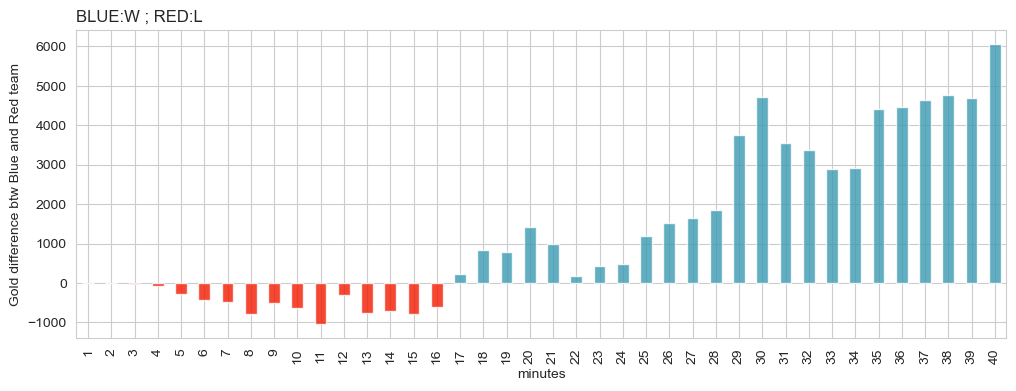

```python
game1 = pd.DataFrame(gold.iloc[0, 2:84].transpose())
game1.columns = ['gold_diff']
game1['time'] = list(range(1,82,1))
game1['MatchHistory'] = np.repeat(df_global['MatchHistory'][0], len(game1))
game1 = game1.merge(df_global, how='left', on='MatchHistory').reset_index().drop(['index'],axis=1)
game1['blueTeam'] = np.where(game1['bResult']==1, 'BLUE:W ; RED:L', 'BLUE:L ; RED:W')
cc = list(map(lambda x: '#F21A00' if x <= 0 else '#3B9AB2', game1['gold_diff']))

plt.rcParams["figure.figsize"] = [12,4]
game1.dropna().plot(x='time', y='gold_diff', kind='bar', color=cc, legend=False, alpha=0.8)
plt.xlabel('minutes')
plt.ylabel('Gold difference btw Blue and Red team')
plt.title('BLUE:W ; RED:L', loc='left')
plt.show()
```

#### 4.1.2 Number of kills vs. time played

This dataset gives the number of kills from a team to the one so the plot below shows :

- +1 for a kill from the blue team to the red team
- -1 for a kill from the red team to the blue team
- I also join this dataset with the global one in order to get the length of the game

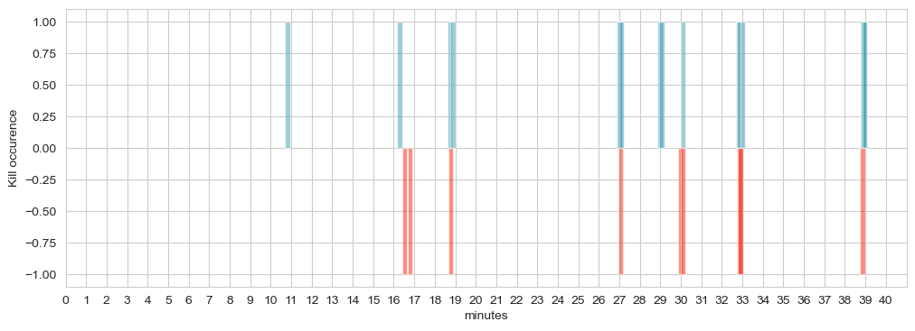

```python
death1 = (death[death['MatchHistory']==df_global['MatchHistory'][0]]
          .merge(df_global, how='left', on='MatchHistory'))
death1['Occurence'] = np.where(death1['TeamColor']=='Blue', 1, -1)
cc = list(map(lambda x: '#F21A00' if x == 'Red' else '#3B9AB2', death1['TeamColor']))
plt.bar(x='Time',height='Occurence',color=cc,width=0.25, data=death1, alpha=0.5)
plt.xlabel('minutes')
plt.ylabel('Kill occurence')
plt.xlim(0,41)
plt.xticks(list(range(0, 41)))
plt.show()
```

#### 4.1.3 Neutral monsters kills

The idea here is to make 2 separate dataframes(blue and red) and then rbind again. It allows to create another label for blue and red separately.

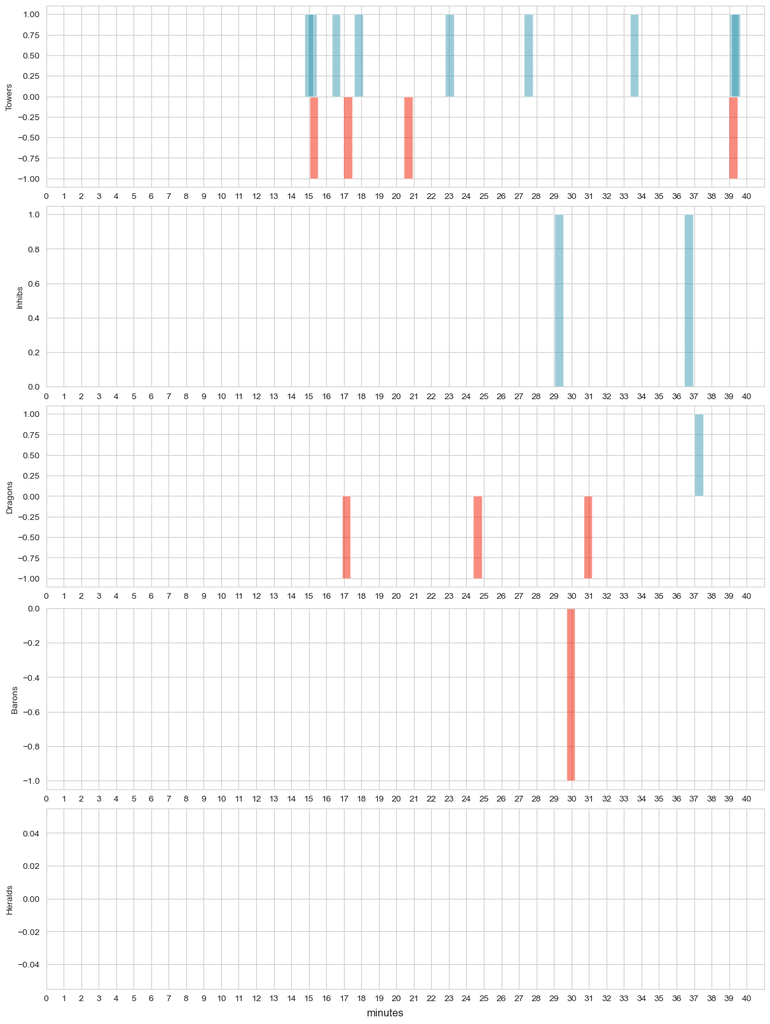

```python
# red
tempR = objects[objects['MatchHistory']==df_global['MatchHistory'][0]]
tempR = tempR[tempR['ObjType'].str.startswith('r')]
tempR = tempR.drop(['MatchHistory', 'ObjType'],axis=1).transpose()
tempR.columns = ['Towers', 'Inhibs', 'Dragons' ,'Barons', 'Heralds']
tempR['Team'] = 'red'
# blue
tempB = objects[objects['MatchHistory']==df_global['MatchHistory'][0]]
tempB = tempB[tempB['ObjType'].str.startswith('b')]
tempB = tempB.drop(['MatchHistory', 'ObjType'],axis=1).transpose()
tempB.columns = ['Towers', 'Inhibs', 'Dragons' ,'Barons', 'Heralds']
tempB['Team'] = 'blue'
# Merge
resObjects = pd.concat([tempR,tempB])

resObjects['Occurence'] = np.where(resObjects['Team']=='blue', 1, -1)
cc = list(map(lambda x: '#F21A00' if x == 'red' else '#3B9AB2', resObjects['Team']))

fig, axs = plt.subplots(5, figsize=(12,16), layout='constrained')

for i,item in enumerate(resObjects.columns[0:5]):
    plt.subplot(5,1,(i+1))
    plt.bar(x=item,height='Occurence',color=cc,width=0.5, data=resObjects, alpha=0.5)
    plt.xlim(0, 41)
    plt.xticks(list(range(0, 41)))
    plt.ylabel(str(item))
fig.supxlabel('minutes')

plt.show()
```

## 5 Gold Values vs. Time played

```python
# Select blue as winners
bW = (df_global[df_global['bResult']==1][['MatchHistory','gamelength','Season','Year','blueTeamTag','redTeamTag']]
      .merge(gold[gold['NameType']=='goldblue'], on='MatchHistory'))
# Select red as winners
rW = (df_global[df_global['rResult']==1][['MatchHistory','gamelength','Season','Year','blueTeamTag','redTeamTag']]
      .merge(gold[gold['NameType']=='goldred'], on='MatchHistory'))
# Merge datasets
allWins = pd.concat([bW, rW], axis=0)
# Split data by year
dfsWins = [x for _, x in allWins.groupby('Year')]
for i in range(0,len(dfsWins)):
    dfsWins[i]=(dfsWins[i].drop(dfsWins[i].iloc[:,0:7],axis=1)).transpose()
    #calculate mean, max and min over all games
    dfsWins[i]['meanWin']=np.nanmean(dfsWins[i],axis=1)
    dfsWins[i]['minWin']=np.nanmin(dfsWins[i],axis=1)
    dfsWins[i]['maxWin']=np.nanmax(dfsWins[i],axis=1)

# Select blue as losers
bL = (df_global[df_global['bResult']==0][['MatchHistory','gamelength','Season','Year','blueTeamTag','redTeamTag']]
      .merge(gold[gold['NameType']=='goldblue'], on='MatchHistory'))
# Select red as losers
rL = (df_global[df_global['rResult']==0][['MatchHistory','gamelength','Season','Year','blueTeamTag','redTeamTag']]
      .merge(gold[gold['NameType']=='goldred'], on='MatchHistory'))
# Merge datasets
allLoses = pd.concat([bL, rL], axis=0)
# Split data by year
dfsLoses = [x for _, x in allLoses.groupby('Year')]
for i in range(0,len(dfsLoses)):
    dfsLoses[i]=(dfsLoses[i].drop(dfsLoses[i].iloc[:,0:7],axis=1)).transpose()
    #calculate mean, max and min over all games
    dfsLoses[i]['meanLose']=np.nanmean(dfsLoses[i],axis=1)
    dfsLoses[i]['minLose']=np.nanmin(dfsLoses[i],axis=1)
    dfsLoses[i]['maxLose']=np.nanmax(dfsLoses[i],axis=1)

# Gold 2014
g2014 = pd.concat([dfsWins[0][['meanWin','minWin','maxWin']], dfsLoses[0][['meanLose','minLose','maxLose']]], axis=1)
g2014['time']=range(1,82)
g2014['year']=2014
# Gold 2015
g2015 = pd.concat([dfsWins[1][['meanWin','minWin','maxWin']], dfsLoses[1][['meanLose','minLose','maxLose']]], axis=1)
g2015['time']=range(1,82)
g2015['year']=2015
# Gold 2016
g2016 = pd.concat([dfsWins[2][['meanWin','minWin','maxWin']], dfsLoses[2][['meanLose','minLose','maxLose']]], axis=1)
g2016['time']=range(1,82)
g2016['year']=2016
# Gold 2017
g2017 = pd.concat([dfsWins[3][['meanWin','minWin','maxWin']], dfsLoses[3][['meanLose','minLose','maxLose']]], axis=1)
g2017['time']=range(1,82)
g2017['year']=2017
# Merge
res=pd.concat([g2014,g2015,g2016,g2017],axis=0)
```

#### 5.1 Mean gold vs. Year

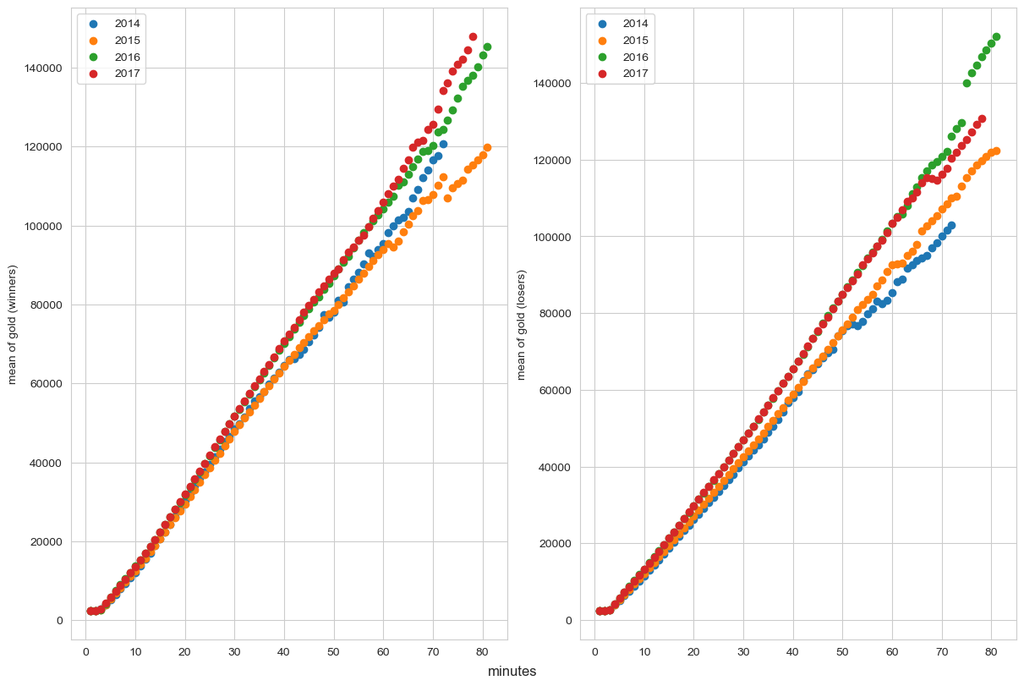

```python
fig, ax = plt.subplots(1, 2, figsize=(12,8), layout='constrained')

plt.subplot(121)
for i,j in res.groupby("year"):
    plt.scatter(j.time,j.meanWin,label=i)
    plt.legend(loc="best")
    plt.ylabel('mean of gold (winners)')

plt.subplot(122)
for i,j in res.groupby("year"):
    plt.scatter(j.time,j.meanLose,label=i)
    plt.legend(loc="best")
    plt.ylabel('mean of gold (losers)')

fig.supxlabel('minutes')
plt.show()
```

We see that the average gold vlaue is similar for 2016 and 2017, and for 2014 and 2015.

#### 5.2 Mean gold vs. Year, breakdown by win/loss

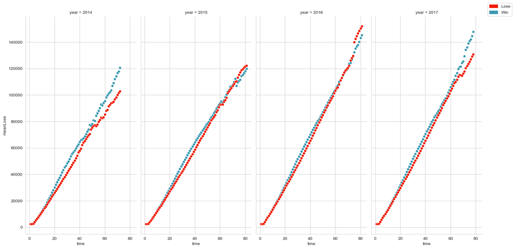

```python
import matplotlib
g = sns.FacetGrid(res, col='year', col_wrap=4, palette='Set1', height=8, aspect=0.5,legend_out=True)
g.map(sns.scatterplot, 'time', 'meanWin', color='#3B9AB2')
g.map(sns.scatterplot, 'time', 'meanLose', color='#F21A00')

name_to_color = {
    'Lose':   '#F21A00',
    'Win':   '#3B9AB2'
}
patches = [matplotlib.patches.Patch(color=v, label=k) for k,v in name_to_color.items()]
plt.legend(handles=patches, bbox_to_anchor=(1.05, 1), loc=3, borderaxespad=0.)
```

Now we see a behavior (common for all years) that is the winning team got more gold (around) mid game than the losing teams. This could be a feature to take into account when predicting if a team will win/lose.

## 6 Bans analysis

Definition of banning in LOL, from [gaming.stackexchange](https://gaming.stackexchange.com/questions/28259/why-are-characters-banned-in-tournament-play-for-dota-likes).

“The origins of banning heroes comes from a match type called -CM, or Captain’s Mode in DoTA. In Captain’s mode, teams take turns banning heroes they don’t want the other team to use whilst picking their own heroes for the match. One person from each team (the person in the first slot) is the one who makes these decisions, so you usually only play CM with a group of people you’re familiar with since it requires a lot of coordination. In professional level play, this becomes extremely important as you want to prevent the other team from picking heroes that they are adept at, or countering the heroes you picked.”

There are also plans from RIOT to increase the bans from 5 (actually) to 10.

As the number of bans has changed through years, the first thing to look is how it has changed.

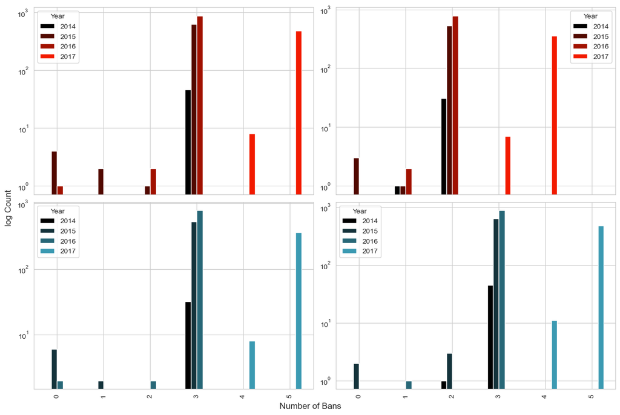

```python
bans_cc = bans.copy()
bans_cc['numBans']=bans_cc.iloc[:,2:].count(axis=1)
df_rbans = bans_cc[bans_cc['TeamColor']=='Red'][['MatchHistory', 'numBans']]
df_bbans = bans_cc[bans_cc['TeamColor']=='Blue'][['MatchHistory', 'numBans']]
df_rgbl = df_global[['MatchHistory', 'League', 'Season', 'Year', 'redTeamTag', 'rResult', 'gamelength']]
df_bgbl = df_global[['MatchHistory', 'League', 'Season', 'Year', 'blueTeamTag', 'bResult', 'gamelength']]
redBans = df_rbans.merge(df_rgbl, on='MatchHistory')
redBans['RES']=np.where(redBans['rResult']==0,'LOSS','WIN')
blueBans = df_bbans.merge(df_bgbl, on='MatchHistory')
blueBans['RES']=np.where(blueBans['bResult']==0,'LOSS','WIN')

df_redcnt=redBans.groupby(['RES', 'numBans','Year'])['numBans'].size().unstack()
rLOSS=df_redcnt.loc[['LOSS']].reset_index(level='RES', drop=True)
rWIN=df_redcnt.loc[['WIN']].reset_index(level='RES', drop=True)

df_bluecnt=blueBans.groupby(['RES', 'numBans','Year'])['numBans'].size().unstack()
bLOSS=df_bluecnt.loc[['LOSS']].reset_index(level='RES', drop=True)
bWIN=df_bluecnt.loc[['WIN']].reset_index(level='RES', drop=True)

rcmap = LinearSegmentedColormap.from_list('name', ['black', '#F21A00'])
bcmap = LinearSegmentedColormap.from_list('name', ['black', '#3B9AB2'])

fig, axs = plt.subplots(2, 2, figsize=(12,8),layout='constrained',sharex=True)

plt.subplot(221)
rLOSS.plot(kind='bar', stacked=False, colormap=rcmap, ax=axs[0,0])
plt.yscale("log")

plt.subplot(222)
rWIN.plot(kind='bar', stacked=False, colormap=rcmap, ax=axs[0,1])
plt.yscale("log")

plt.subplot(223)
bLOSS.plot(kind='bar', stacked=False, colormap=bcmap, ax=axs[1,0])
plt.yscale("log")
plt.xlabel("")

plt.subplot(224)
bWIN.plot(kind='bar', stacked=False, colormap=bcmap, ax=axs[1,1])
plt.yscale("log")
plt.xlabel("")

fig.supylabel('log Count')
fig.supxlabel('Number of Bans')
plt.show()
```

As we see, the number of bans has incresed in 2017 from 3 to 5.